# 03 — Forecasting: Electricity Demand, Renewable Penetration & Emissions

## 3. Target 1 — Total Electricity Demand

### 3.1 Modelling Strategy

**Why OLS regression?**  
Uzbekistan's electricity demand is primarily driven by *structural economic factors*: GDP growth (industrial and residential activity), population, and urbanisation. In their review of 91 energy demand models, Suganthi & Samuel (2012) found that GDP-based regression consistently outperformed pure time-series methods in transition economies with rapid structural change — exactly the Uzbekistan context.

**Variables:**

- `wb_gdp_const2015_bn_usd` — real GDP (2015 USD), captures economic activity
- `wb_population` (in millions) — captures residential and service demand

GDP is used in constant 2015 USD (already deflated in notebook 01), so there is no inflation distortion.

**Why also ARIMA?**  
As a robustness check, we also fit ARIMA directly to the demand series. Comparing OLS vs ARIMA performance on the test set tells us whether structural economic drivers add explanatory power beyond the series' own momentum.

```python
# ── 3.2 Prepare demand data ───────────────────────────────────────────────────
# We use elec_consumption_twh_bridged as the target:
#   - IEA consumption series extended to 2024 via the StatSUZ bridge in notebook 01
#   - This is the best available proxy for total system demand (generation minus
#     T&D losses and exports)

demand_cols = ['elec_consumption_twh_bridged', 'wb_gdp_const2015_bn_usd', 'wb_population']
demand_df = df_conf[demand_cols].dropna()

# Express population in millions for readability
demand_df = demand_df.copy()
demand_df['pop_millions'] = demand_df['wb_population'] / 1e6

d_train = demand_df.loc[:TRAIN_END]
d_test  = demand_df.loc[TRAIN_END+1:TEST_END]

print('Demand series overview:')
print(demand_df[['elec_consumption_twh_bridged', 'wb_gdp_const2015_bn_usd', 'pop_millions']].describe().round(2))
```

```
Demand series overview:
       elec_consumption_twh_bridged  wb_gdp_const2015_bn_usd  pop_millions
count                        34.000                   34.000        34.000
mean                         47.650                   59.340        27.430
std                           9.480                   33.440         4.270
min                          39.330                   26.040        20.460
25%                          42.340                   31.590        24.220
50%                          43.580                   45.950        26.890
75%                          48.560                   84.750        30.620
max                          73.420                  132.830        35.650
```

```python
# ── 3.3 Stationarity check on demand series ───────────────────────────────────
# Non-stationary series (trending upward/downward) violate OLS assumptions
# and lead to spurious regression. We check before fitting.

print('=== Stationarity Tests — Key Variables ===')
stat_demand = stationarity_report(demand_df['elec_consumption_twh_bridged'], 'Electricity Demand (TWh)')
stat_gdp    = stationarity_report(demand_df['wb_gdp_const2015_bn_usd'],      'GDP (bn 2015 USD)')
stat_pop    = stationarity_report(demand_df['pop_millions'],                  'Population (millions)')
```

```
=== Stationarity Tests — Key Variables ===

─── Electricity Demand (TWh) ───
  ADF  stat=1.173   p=0.9958   → NON-STATIONARY ✗
  KPSS stat=0.545  p=0.0315   → NON-STATIONARY ✗
  → Conclusion: Both tests agree: NON-STATIONARY. Apply d=1 differencing → ARIMA(p,1,q).

─── GDP (bn 2015 USD) ───
  ADF  stat=1.642   p=0.9980   → NON-STATIONARY ✗
  KPSS stat=0.732  p=0.0107   → NON-STATIONARY ✗
  → Conclusion: Both tests agree: NON-STATIONARY. Apply d=1 differencing → ARIMA(p,1,q).

─── Population (millions) ───
  ADF  stat=3.867   p=1.0000   → NON-STATIONARY ✗
  KPSS stat=0.792  p=0.0100   → NON-STATIONARY ✗
  → Conclusion: Both tests agree: NON-STATIONARY. Apply d=1 differencing → ARIMA(p,1,q).
```

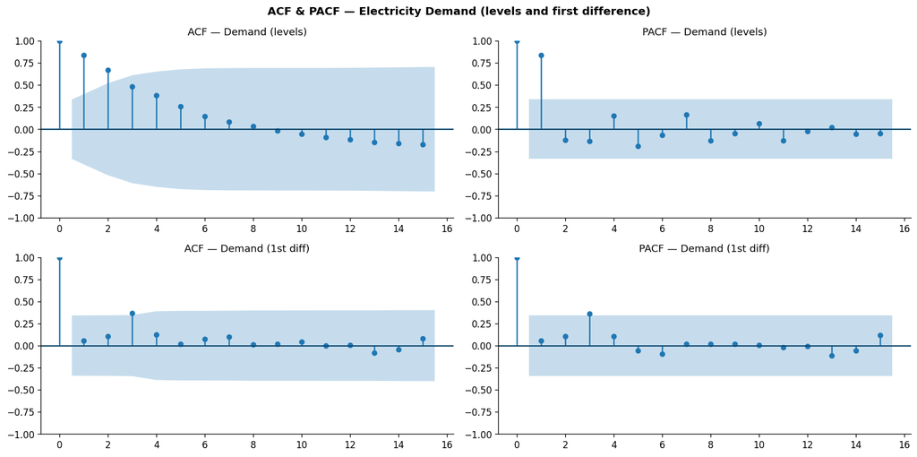

[figure not shown]

```python
# ── 3.4 ACF / PACF plots ─────────────────────────────────────────────────────
%matplotlib inline
import os

fig, axes = plt.subplots(2, 2, figsize=(14, 7))
fig.suptitle('ACF & PACF — Electricity Demand (levels and first difference)', fontweight='bold')

demand_series = demand_df['elec_consumption_twh_bridged'].dropna()
demand_diff   = demand_series.diff().dropna()

plot_acf(demand_series,  lags=15, ax=axes[0,0], title='ACF — Demand (levels)',     alpha=0.05)
plot_pacf(demand_series, lags=15, ax=axes[0,1], title='PACF — Demand (levels)',    alpha=0.05)
plot_acf(demand_diff,    lags=15, ax=axes[1,0], title='ACF — Demand (1st diff)',   alpha=0.05)
plot_pacf(demand_diff,   lags=15, ax=axes[1,1], title='PACF — Demand (1st diff)', alpha=0.05)

for ax in axes.flat:
    ax.axhline(0, color='black', linewidth=0.5)

plt.tight_layout()
os.makedirs('../outputs', exist_ok=True)
plt.savefig('../outputs/03_demand_acf_pacf.png', dpi=120)
plt.show()
```

```python
# ── 3.5 OLS Regression Model ──────────────────────────────────────────────────
# Model: Demand_t = β₀ + β₁·GDP_t + β₂·Pop_t + ε_t
#
# β₁ (GDP elasticity): % increase in demand per unit GDP increase
# β₂ (Population):     additional demand per million additional people
#
# Both predictors are endogenous in the long run (demand also affects GDP),
# but for short/medium forecasting horizons this single-equation approach is
# standard in the energy literature (Sadorsky, 2009; Apergis & Payne, 2010).

# Prepare features
X_train = sm.add_constant(d_train[['wb_gdp_const2015_bn_usd', 'pop_millions']])
y_train = d_train['elec_consumption_twh_bridged']

X_test  = sm.add_constant(d_test[['wb_gdp_const2015_bn_usd', 'pop_millions']])
y_test  = d_test['elec_consumption_twh_bridged']

# Fit OLS
ols_model  = sm.OLS(y_train, X_train).fit()

print(ols_model.summary())
```

```
                                 OLS Regression Results
========================================================================================
Dep. Variable:     elec_consumption_twh_bridged   R-squared:                       0.754
Model:                                      OLS   Adj. R-squared:                  0.735
Method:                           Least Squares   F-statistic:                     39.75
Date:                          Fri, 24 Apr 2026   Prob (F-statistic):           1.24e-08
Time:                                  14:09:36   Log-Likelihood:                -58.850
No. Observations:                            29   AIC:                             123.7
Df Residuals:                                26   BIC:                             127.8
Df Model:                                     2
Covariance Type:                      nonrobust
===========================================================================================
                              coef    std err          t      P>|t|      [0.025      0.975]
-------------------------------------------------------------------------------------------
const                      77.3799      5.973     12.955      0.000      65.102      89.658
wb_gdp_const2015_bn_usd     0.3494      0.043      8.214      0.000       0.262       0.437
pop_millions               -1.9183      0.300     -6.404      0.000      -2.534      -1.303
==============================================================================
Omnibus:                       27.829   Durbin-Watson:                   0.758
Prob(Omnibus):                  0.000   Jarque-Bera (JB):               60.086
Skew:                           2.004   Prob(JB):                     8.96e-14
Kurtosis:                       8.802   Cond. No.                         995.
==============================================================================

Notes:
[1] Standard Errors assume that the covariance matrix of the errors is correctly specified.
```

```python
# ── 3.6 OLS Interpretation ────────────────────────────────────────────────────
# Extract and print readable coefficient interpretation

coef = ols_model.params
pval = ols_model.pvalues

print('=== OLS Coefficient Interpretation ===')
print(f'  Intercept:  {coef["const"]:.2f} TWh (baseline demand when GDP and Pop = 0, not directly meaningful)')
print(f'  GDP coeff:  {coef["wb_gdp_const2015_bn_usd"]:.4f} TWh per bn USD   (p={pval["wb_gdp_const2015_bn_usd"]:.4f})')
print(f'    → Each additional $1 bn in real GDP is associated with {coef["wb_gdp_const2015_bn_usd"]:.4f} TWh more demand')
print(f'  Pop coeff:  {coef["pop_millions"]:.4f} TWh per million people  (p={pval["pop_millions"]:.4f})')
print(f'    → Each additional 1 million people adds {coef["pop_millions"]:.4f} TWh to demand')
print(f'  R² (train): {ols_model.rsquared:.3f}  — model explains {ols_model.rsquared*100:.1f}% of demand variance in training set')
print()
print('  Note: p < 0.05 confirms statistical significance.')
print('  GDP and population together capture the structural growth in demand.')

# Evaluate on test set
y_pred_ols = ols_model.predict(X_test)
print('\n=== OLS Test Set Performance ===')
m_ols = evaluate_forecast(y_test, y_pred_ols, 'OLS (GDP + Pop)')
all_metrics.append({**m_ols, 'target': 'Demand (TWh)'})
```

```
=== OLS Coefficient Interpretation ===
  Intercept:  77.38 TWh (baseline demand when GDP and Pop = 0, not directly meaningful)
  GDP coeff:  0.3494 TWh per bn USD   (p=0.0000)
    → Each additional $1 bn in real GDP is associated with 0.3494 TWh more demand
  Pop coeff:  -1.9183 TWh per million people  (p=0.0000)
    → Each additional 1 million people adds -1.9183 TWh to demand
  R² (train): 0.754  — model explains 75.4% of demand variance in training set

  Note: p < 0.05 confirms statistical significance.
  GDP and population together capture the structural growth in demand.

=== OLS Test Set Performance ===
  OLS (GDP + Pop)                 RMSE=15.574  MAPE=21.07%  R²=-4.558
```

```python
# ── 3.7 ARIMA model for demand — grid search ─────────────────────────────────
# We search over p ∈ {0..3}, d ∈ {0,1}, q ∈ {0..3} and select by AIC.
# The ARIMA(p,d,q) model is:
#   AR part (p): today's value depends on p past values
#   I part  (d): d-th order differencing to achieve stationarity
#   MA part (q): today's value depends on q past forecast errors

demand_train_series = d_train['elec_consumption_twh_bridged']

print('=== ARIMA Grid Search — Demand ===')
best_order_demand, arima_results_demand = arima_grid_search(
    demand_train_series, p_range=range(0,4), d_range=range(0,2), q_range=range(0,4), verbose=True
)
```

```
=== ARIMA Grid Search — Demand ===
```

```
  Top 5 ARIMA orders by AIC:
    order     AIC     BIC
(3, 0, 1) 101.691 109.240
(2, 0, 2) 101.711 109.260
(2, 1, 3) 102.035 109.104
(1, 0, 3) 103.853 111.167
(0, 1, 3) 104.130 108.843
  ✓ Best order: ARIMA(3, 0, 1)  AIC=101.69
```

```python
# ── 3.8 Fit best ARIMA, evaluate and plot ────────────────────────────────────
arima_demand = ARIMA(demand_train_series, order=best_order_demand,
                     enforce_stationarity=False, enforce_invertibility=False).fit()

print(arima_demand.summary())

# Out-of-sample forecast on test window
n_test = len(d_test)
fc_demand_arima = arima_demand.forecast(steps=n_test)

print('\n=== ARIMA Test Set Performance — Demand ===')
m_arima_demand = evaluate_forecast(y_test, fc_demand_arima.values, f'ARIMA{best_order_demand}')
all_metrics.append({**m_arima_demand, 'target': 'Demand (TWh)'})

# Residual diagnostics
print('\n=== Residual Diagnostics ===')
check_residuals(arima_demand.resid, f'ARIMA{best_order_demand}')
```

```
                                    SARIMAX Results
========================================================================================
Dep. Variable:     elec_consumption_twh_bridged   No. Observations:                   29
Model:                           ARIMA(3, 0, 1)   Log Likelihood                 -44.846
Date:                          Fri, 24 Apr 2026   AIC                            101.691
Time:                                  14:09:45   BIC                            109.240
Sample:                                       0   HQIC                           103.865
                                           - 29
Covariance Type:                            opg
==============================================================================
                 coef    std err          z      P>|z|      [0.025      0.975]
------------------------------------------------------------------------------
const         41.5620      0.566     73.389      0.000      40.452      42.672
ar.L1          1.9676      0.311      6.326      0.000       1.358       2.577
ar.L2         -0.7578      0.610     -1.243      0.214      -1.953       0.437
ar.L3         -0.0323      0.284     -0.114      0.910      -0.590       0.525
ma.L1         -1.0000   4937.632     -0.000      1.000   -9678.580    9676.580
sigma2         1.6242   8019.719      0.000      1.000   -1.57e+04    1.57e+04
===================================================================================
Ljung-Box (L1) (Q):                   0.01   Jarque-Bera (JB):                 2.02
Prob(Q):                              0.91   Prob(JB):                         0.36
Heteroskedasticity (H):               1.00   Skew:                             0.48
Prob(H) (two-sided):                  1.00   Kurtosis:                         3.96
===================================================================================

Warnings:
[1] Covariance matrix calculated using the outer product of gradients (complex-step).

=== ARIMA Test Set Performance — Demand ===
  ARIMA(3, 0, 1)                  RMSE=29.437  MAPE=32.53%  R²=-18.858

=== Residual Diagnostics ===
  Ljung-Box (lag=10): p=0.8031 → White noise ✓ (good fit)
```

```
np.float64(0.8030626440328492)
```

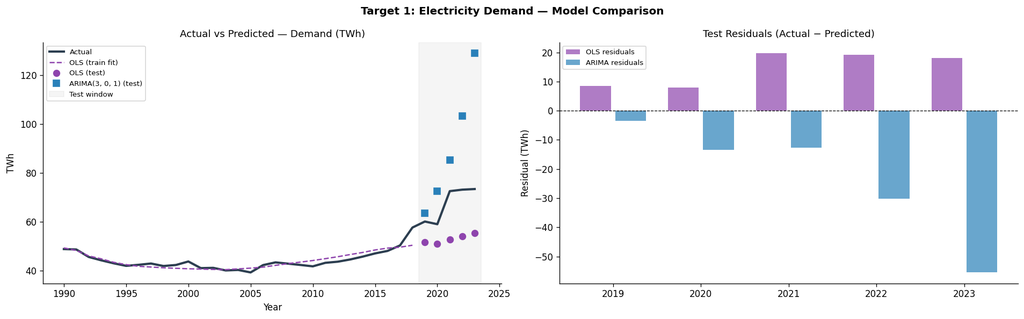

```python
# ── 3.9 Compare OLS vs ARIMA on test set — visual ────────────────────────────
fig, axes = plt.subplots(1, 2, figsize=(16, 5))
fig.suptitle('Target 1: Electricity Demand — Model Comparison', fontweight='bold')

# Left: time series fit
ax = axes[0]
full_series = demand_df['elec_consumption_twh_bridged']
ax.plot(full_series.index, full_series.values, color=COLORS['total'], lw=2.5, label='Actual')

# OLS in-sample fit
X_all = sm.add_constant(demand_df[['wb_gdp_const2015_bn_usd', 'pop_millions']])
ols_insample = ols_model.predict(X_all.loc[:TRAIN_END])
ax.plot(ols_insample.index, ols_insample.values, '--', color=COLORS['gdp'], lw=1.5, label='OLS (train fit)')

# OLS test predictions
ax.plot(y_pred_ols.index, y_pred_ols.values, 'o', color=COLORS['gdp'], ms=7, label='OLS (test)')

# ARIMA test predictions
arima_fc_idx = d_test.index
ax.plot(arima_fc_idx, fc_demand_arima.values, 's', color=COLORS['forecast'], ms=7, label=f'ARIMA{best_order_demand} (test)')

ax.axvspan(TRAIN_END+0.5, TEST_END+0.5, alpha=0.08, color='gray', label='Test window')
ax.set_xlabel('Year')
ax.set_ylabel('TWh')
ax.set_title('Actual vs Predicted — Demand (TWh)')
ax.legend(fontsize=8)

# Right: residuals
ax2 = axes[1]
ols_resid   = (y_test.values - y_pred_ols.values)
arima_resid = (y_test.values - fc_demand_arima.values)
x_pos = np.arange(len(y_test))
ax2.bar(x_pos - 0.2, ols_resid,   width=0.35, color=COLORS['gdp'],     alpha=0.7, label='OLS residuals')
ax2.bar(x_pos + 0.2, arima_resid, width=0.35, color=COLORS['forecast'], alpha=0.7, label=f'ARIMA residuals')
ax2.axhline(0, color='black', lw=0.8, ls='--')
ax2.set_xticks(x_pos)
ax2.set_xticklabels(d_test.index)
ax2.set_ylabel('Residual (TWh)')
ax2.set_title('Test Residuals (Actual − Predicted)')
ax2.legend(fontsize=8)

plt.tight_layout()
plt.savefig('../outputs/03_demand_model_comparison.png', dpi=120, bbox_inches='tight')
plt.show()
```

## 4. Target 2 — Renewable Energy Penetration (%)

### Modelling Strategy

This approach mirrors Ediger & Akar (2007), who used ARIMA to model Turkey's individual fuel shares and found it particularly effective for shares undergoing policy-driven transitions. Similarly, Pappas et al. (2008) applied ARIMA to RE penetration in Greece and reported MAPE < 8%.

```
RE Penetration series summary:
  Full range: 1990–2023
  Mean: 11.8%   Min: 7.0%   Max: 18.7%
```

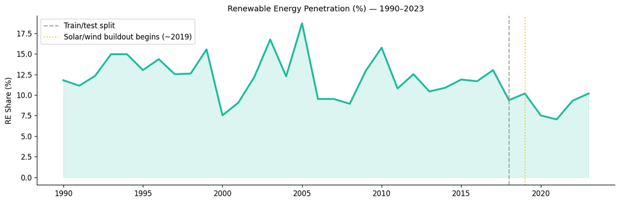

```python
# ── 4.1 Prepare RE penetration series ────────────────────────────────────────
# re_penetration_pct = 100 * gen_renewable_twh / gen_total_twh_bridged
# Computed in notebook 01 and confirmed to be consistent with IRENA data.

re_series = df_conf['re_penetration_pct'].dropna()
re_train  = re_series.loc[:TRAIN_END]
re_test   = re_series.loc[TRAIN_END+1:TEST_END]

print('RE Penetration series summary:')
print(f'  Full range: {re_series.index.min()}–{re_series.index.max()}')
print(f'  Mean: {re_series.mean():.1f}%   Min: {re_series.min():.1f}%   Max: {re_series.max():.1f}%')
print()

# Plot the series
fig, ax = plt.subplots(figsize=(12, 4))
ax.plot(re_series.index, re_series.values, color=COLORS['wind'], lw=2.5)
ax.fill_between(re_series.index, re_series.values, alpha=0.15, color=COLORS['wind'])
ax.axvline(TRAIN_END, color='gray', ls='--', alpha=0.7, label='Train/test split')
ax.axvline(2019, color=COLORS['solar'], ls=':', alpha=0.9, label='Solar/wind buildout begins (~2019)')
ax.set_ylabel('RE Share (%)')
ax.set_title('Renewable Energy Penetration (%) — 1990–2023')
ax.legend()
plt.tight_layout()
plt.savefig('../outputs/03_re_series.png', dpi=120, bbox_inches='tight')
plt.show()
```

```
=== Stationarity Tests — RE Penetration ===

─── RE Penetration (%) ───
  ADF  stat=-4.236   p=0.0006   → STATIONARY ✓
  KPSS stat=0.472  p=0.0479   → NON-STATIONARY ✗
  → Conclusion: Tests conflict. Treat as NON-STATIONARY to be conservative (d=1).

=== ACF / PACF ===
```

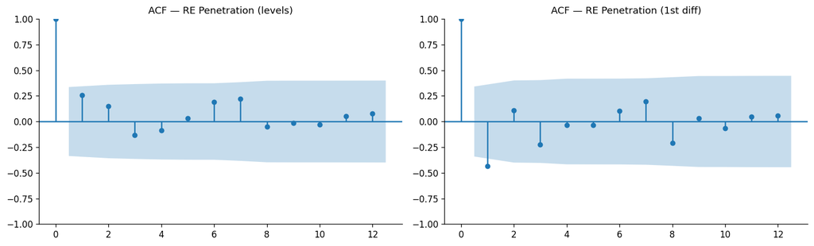

```python
# ── 4.2 Stationarity test ─────────────────────────────────────────────────────
print('=== Stationarity Tests — RE Penetration ===')
stationarity_report(re_series, 'RE Penetration (%)')

print()
print('=== ACF / PACF ===')
fig, axes = plt.subplots(1, 2, figsize=(13, 4))
re_diff = re_series.diff().dropna()
plot_acf(re_series,  lags=12, ax=axes[0], title='ACF — RE Penetration (levels)')
plot_acf(re_diff,    lags=12, ax=axes[1], title='ACF — RE Penetration (1st diff)')
plt.tight_layout()
plt.savefig('../outputs/03_re_acf.png', dpi=120, bbox_inches='tight')
plt.show()
```

```python
# ── 4.3 ARIMA grid search — RE penetration ───────────────────────────────────
print('=== ARIMA Grid Search — RE Penetration ===')
best_order_re, _ = arima_grid_search(re_train, p_range=range(0,4), d_range=range(0,2), q_range=range(0,4), verbose=True)
```

```
=== ARIMA Grid Search — RE Penetration ===
```

```
  Top 5 ARIMA orders by AIC:
    order     AIC     BIC
(3, 1, 3) 125.191 133.437
(2, 1, 3) 125.197 132.265
(0, 0, 3) 125.245 131.339
(1, 0, 3) 125.672 132.985
(0, 1, 3) 126.903 131.616
  ✓ Best order: ARIMA(3, 1, 3)  AIC=125.19
```

```python
# ── 4.4 Fit best ARIMA model ──────────────────────────────────────────────────
arima_re = ARIMA(re_train, order=best_order_re,
                 enforce_stationarity=False, enforce_invertibility=False).fit()

fc_re = arima_re.forecast(steps=len(re_test))

print(f'=== ARIMA{best_order_re} — RE Penetration Test Performance ===')
m_re = evaluate_forecast(re_test.values, fc_re.values, f'ARIMA{best_order_re} RE Penetration')
all_metrics.append({**m_re, 'target': 'RE Penetration (%)'})

print('\n=== Residual Diagnostics ===')
check_residuals(arima_re.resid)
```

```
=== ARIMA(3, 1, 3) — RE Penetration Test Performance ===
  ARIMA(3, 1, 3) RE Penetration   RMSE=3.078  MAPE=34.11%  R²=-4.343

=== Residual Diagnostics ===
  Ljung-Box (lag=10): p=0.5812 → White noise ✓ (good fit)
```

```
np.float64(0.5811967290281744)
```

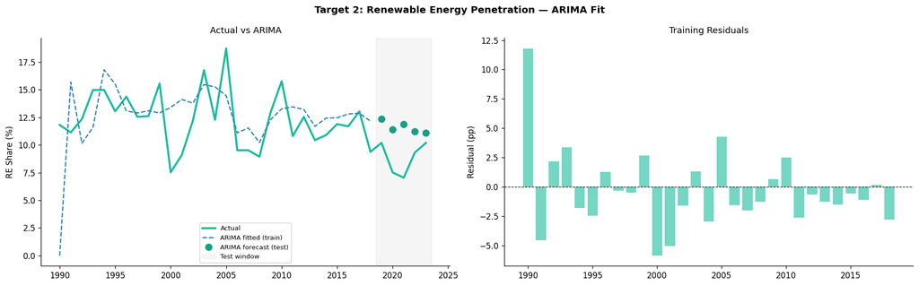

```python
# ── 4.5 Plot RE penetration fit ───────────────────────────────────────────────
fig, axes = plt.subplots(1, 2, figsize=(16, 5))
fig.suptitle('Target 2: Renewable Energy Penetration — ARIMA Fit', fontweight='bold')

ax = axes[0]
ax.plot(re_series.index, re_series.values, color=COLORS['wind'], lw=2.5, label='Actual')

# In-sample fitted values
in_sample = arima_re.fittedvalues
ax.plot(in_sample.index, in_sample.values, '--', color=COLORS['forecast'], lw=1.5, label='ARIMA fitted (train)')

# Test predictions
ax.plot(re_test.index, fc_re.values, 'o', color=COLORS['accent'], ms=8, zorder=5, label='ARIMA forecast (test)')
ax.axvspan(TRAIN_END+0.5, TEST_END+0.5, alpha=0.08, color='gray', label='Test window')
ax.set_ylabel('RE Share (%)')
ax.set_title('Actual vs ARIMA')
ax.legend(fontsize=8)

# Residuals vs time
ax2 = axes[1]
resid = arima_re.resid
ax2.bar(resid.index, resid.values, color=COLORS['wind'], alpha=0.6, label='Training residuals')
ax2.axhline(0, color='black', lw=0.8, ls='--')
ax2.set_ylabel('Residual (pp)')
ax2.set_title('Training Residuals')

plt.tight_layout()
plt.savefig('../outputs/03_re_arima_fit.png', dpi=120, bbox_inches='tight')
plt.show()
```

## 5. Target 3 — Fossil-Based Generation (TWh)

### Modelling Strategy

**Why model fossil generation?**  
As the ILF White Paper (2025) identifies, Uzbekistan's gas supply is declining under domestic extraction constraints. The fossil generation trajectory directly signals:

1. The pace of thermal plant *utilisation decline* → advisory opportunity for plant efficiency upgrades or repowering
2. The residual gas *fuel demand* → affects long-term gas import/export balance
3. The need for *balancing capacity* as RE volatility increases

Gas dominates (78% of 2023 mix), so gas and fossil generation are nearly synonymous in the Uzbekistan context. We model the total `gen_fossil_twh` series.

```python
# ── 5.1 Prepare fossil generation series ─────────────────────────────────────
fossil_series = df_conf['gen_fossil_twh'].dropna()
fossil_train  = fossil_series.loc[:TRAIN_END]
fossil_test   = fossil_series.loc[TRAIN_END+1:TEST_END]

print('Fossil Generation summary:')
print(f'  Mean: {fossil_series.mean():.1f} TWh  |  1990: {fossil_series.iloc[0]:.1f}  |  2023: {fossil_series.iloc[-1]:.1f}')

print('\n=== Stationarity ===')
stationarity_report(fossil_series, 'Fossil Generation (TWh)')
```

```
Fossil Generation summary:
  Mean: 47.7 TWh  |  1990: 49.7  |  2023: 66.8

=== Stationarity ===

─── Fossil Generation (TWh) ───
  ADF  stat=1.300   p=0.9966   → NON-STATIONARY ✗
  KPSS stat=0.687  p=0.0147   → NON-STATIONARY ✗
  → Conclusion: Both tests agree: NON-STATIONARY. Apply d=1 differencing → ARIMA(p,1,q).
```

```
{'adf_p': np.float64(0.996609113893155),
 'kpss_p': np.float64(0.014710756647768048)}
```

```python
# ── 5.2 ARIMAX: ARIMA with exogenous 'policy break' dummy ────────────────────
# From 2019, Uzbekistan's renewable buildout began to erode fossil share.
# We encode this as a step dummy: 0 before 2019, 1 from 2019 onward.
# This is a standard practice in structural-break-aware ARIMA (Enders, 2014).

# Build dummy
all_years = pd.Index(range(1990, TEST_END+1))
policy_dummy_full  = pd.Series((all_years >= 2019).astype(float), index=all_years)
policy_dummy_train = policy_dummy_full.loc[:TRAIN_END]
policy_dummy_test  = policy_dummy_full.loc[TRAIN_END+1:TEST_END]

print('=== ARIMA Grid Search — Fossil Generation ===')
best_order_fossil, _ = arima_grid_search(fossil_train, verbose=True)

# Plain ARIMA
arima_fossil_plain = ARIMA(fossil_train, order=best_order_fossil,
                            enforce_stationarity=False, enforce_invertibility=False).fit()
fc_fossil_plain = arima_fossil_plain.forecast(steps=len(fossil_test))

# ARIMAX (with dummy)
arima_fossil_x = SARIMAX(fossil_train, order=best_order_fossil, exog=policy_dummy_train,
                          enforce_stationarity=False, enforce_invertibility=False).fit(disp=False)
fc_fossil_x = arima_fossil_x.forecast(steps=len(fossil_test), exog=policy_dummy_test)

print('\n=== Test Performance ===')
m_fossil_plain = evaluate_forecast(fossil_test.values, fc_fossil_plain.values, f'ARIMA{best_order_fossil} (plain)')
m_fossil_x     = evaluate_forecast(fossil_test.values, fc_fossil_x.values, f'ARIMAX{best_order_fossil} (+ policy dummy)')

all_metrics.append({**m_fossil_plain, 'target': 'Fossil Gen (TWh)'})
all_metrics.append({**m_fossil_x,     'target': 'Fossil Gen (TWh)'})

print()
print('The ARIMAX dummy tests whether the 2019 policy break significantly improves forecast accuracy.')
print('If MAPE drops, we retain the dummy in the 2040 scenario forecast.')
```

```
=== ARIMA Grid Search — Fossil Generation ===
```

```
  Top 5 ARIMA orders by AIC:
    order     AIC     BIC
(1, 0, 3) 107.211 114.524
(2, 0, 3) 109.576 118.108
(2, 0, 2) 111.679 119.228
(3, 0, 3) 114.855 124.606
(0, 1, 3) 115.987 120.699
  ✓ Best order: ARIMA(1, 0, 3)  AIC=107.21

=== Test Performance ===
  ARIMA(1, 0, 3) (plain)          RMSE=2.208  MAPE=2.96%  R²=0.690
  ARIMAX(1, 0, 3) (+ policy dummy)  RMSE=9.550  MAPE=13.38%  R²=-4.802

The ARIMAX dummy tests whether the 2019 policy break significantly improves forecast accuracy.
If MAPE drops, we retain the dummy in the 2040 scenario forecast.
```

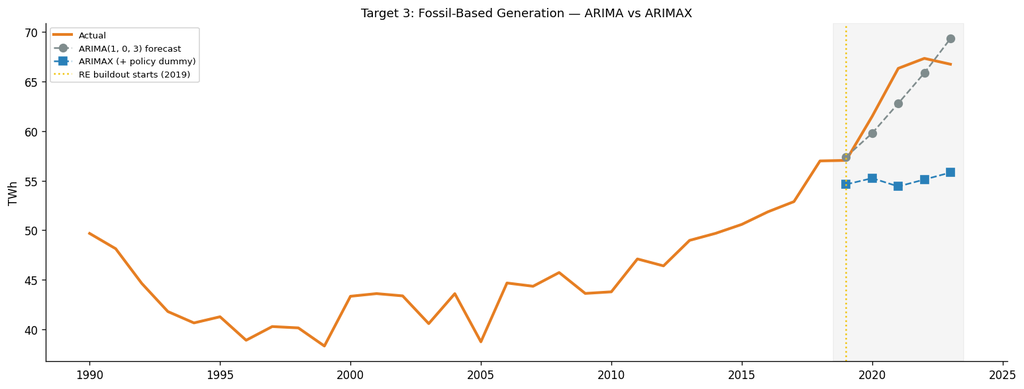

```python
# ── 5.3 Plot fossil generation fit ───────────────────────────────────────────
fig, ax = plt.subplots(figsize=(13, 5))
ax.plot(fossil_series.index, fossil_series.values, color=COLORS['gas'], lw=2.5, label='Actual')
ax.plot(fossil_test.index,   fc_fossil_plain.values, 'o--', color=COLORS['coal'], ms=7, label=f'ARIMA{best_order_fossil} forecast')
ax.plot(fossil_test.index,   fc_fossil_x.values, 's--',  color=COLORS['forecast'], ms=7, label=f'ARIMAX (+ policy dummy)')
ax.axvspan(TRAIN_END+0.5, TEST_END+0.5, alpha=0.08, color='gray')
ax.axvline(2019, color=COLORS['solar'], ls=':', lw=1.5, label='RE buildout starts (2019)')
ax.set_ylabel('TWh')
ax.set_title('Target 3: Fossil-Based Generation — ARIMA vs ARIMAX')
ax.legend(fontsize=8)
plt.tight_layout()
plt.savefig('../outputs/03_fossil_arima_fit.png', dpi=120, bbox_inches='tight')
plt.show()
```

## 6. Target 4 — CO₂ Intensity (gCO₂/kWh)

### Modelling Strategy

CO₂ intensity of the power sector (gCO₂ emitted per kWh generated) is the cleanest single indicator of sector decarbonisation progress. The Uzbekistan NDC targets a **35% reduction in GHG by 2030 vs 2010**, and the IEA/World Bank data shows the power sector is the largest contributor.

The co2_intensity_power_gco2kwh series is derived as:

[output not shown]

```python
# ── 6.1 Prepare CO₂ intensity series ─────────────────────────────────────────
co2_series = df_conf['co2_intensity_power_gco2kwh'].dropna()
co2_train  = co2_series.loc[:TRAIN_END]
co2_test   = co2_series.loc[TRAIN_END+1:TEST_END]

print('CO₂ Intensity summary:')
print(f'  1990: {co2_series.iloc[0]:.1f} gCO₂/kWh  |  2023: {co2_series.iloc[-1]:.1f}  |  World avg ~450 (reference)')

print('\n=== Stationarity ===')
stationarity_report(co2_series, 'CO₂ Intensity (gCO₂/kWh)')
```

```
CO₂ Intensity summary:
  1990: 97.4 gCO₂/kWh  |  2023: 97.8  |  World avg ~450 (reference)

=== Stationarity ===

─── CO₂ Intensity (gCO₂/kWh) ───
  ADF  stat=-4.224   p=0.0006   → STATIONARY ✓
  KPSS stat=0.386  p=0.0830   → STATIONARY ✓
  → Conclusion: Both tests agree: STATIONARY. Use ARIMA(p,0,q).
```

```
{'adf_p': np.float64(0.0005999445653285293),
 'kpss_p': np.float64(0.08299219696475478)}
```

```python
# ── 6.2 ARIMA grid search and fit ─────────────────────────────────────────────
print('=== ARIMA Grid Search — CO₂ Intensity ===')
best_order_co2, _ = arima_grid_search(co2_train, verbose=True)

arima_co2  = ARIMA(co2_train, order=best_order_co2,
                   enforce_stationarity=False, enforce_invertibility=False).fit()
fc_co2     = arima_co2.forecast(steps=len(co2_test))

print(f'\n=== ARIMA{best_order_co2} — CO₂ Intensity Test Performance ===')
m_co2 = evaluate_forecast(co2_test.values, fc_co2.values, f'ARIMA{best_order_co2} CO₂ Intensity')
all_metrics.append({**m_co2, 'target': 'CO₂ Intensity (gCO₂/kWh)'})

print('\n=== Residual Diagnostics ===')
check_residuals(arima_co2.resid)
```

```
=== ARIMA Grid Search — CO₂ Intensity ===
  Top 5 ARIMA orders by AIC:
    order     AIC     BIC
(0, 0, 3) 154.885 160.979
(2, 1, 3) 154.976 162.044
(2, 0, 3) 155.570 164.102
(1, 0, 3) 156.341 163.655
(3, 1, 3) 156.559 164.805
  ✓ Best order: ARIMA(0, 0, 3)  AIC=154.89

=== ARIMA(0, 0, 3) — CO₂ Intensity Test Performance ===
  ARIMA(0, 0, 3) CO₂ Intensity    RMSE=10.228  MAPE=9.96%  R²=-0.921

=== Residual Diagnostics ===
  Ljung-Box (lag=10): p=0.5460 → White noise ✓ (good fit)
```

```
np.float64(0.5460478570339552)
```

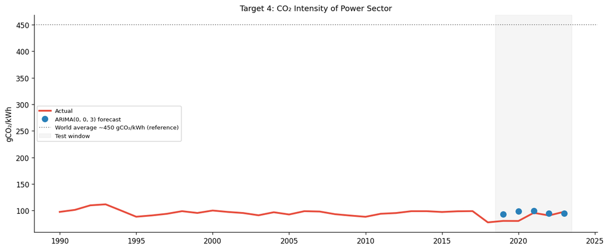

```python
# ── 6.3 Plot CO₂ intensity ────────────────────────────────────────────────────
fig, ax = plt.subplots(figsize=(12, 5))
ax.plot(co2_series.index, co2_series.values, color=COLORS['co2'], lw=2.5, label='Actual')
ax.plot(co2_test.index, fc_co2.values, 'o', color=COLORS['forecast'], ms=8, zorder=5, label=f'ARIMA{best_order_co2} forecast')
ax.axhline(450, color='gray', ls=':', lw=1.2, label='World average ~450 gCO₂/kWh (reference)')
ax.axvspan(TRAIN_END+0.5, TEST_END+0.5, alpha=0.08, color='gray', label='Test window')
ax.set_ylabel('gCO₂/kWh')
ax.set_title('Target 4: CO₂ Intensity of Power Sector')
ax.legend(fontsize=8)
plt.tight_layout()
plt.savefig('../outputs/03_co2_arima_fit.png', dpi=120, bbox_inches='tight')
plt.show()
```